# **Stochastic simulation**

```python
!pip install mplcyberpunk
```

```python
import pandas as pd
import numpy as np
import math
import matplotlib.pyplot as plt
import seaborn as sns
from random import sample
#!pip install mplcyberpunk
import mplcyberpunk
plt.style.use("cyberpunk")
#sns.set()
```

```python
class StochasticSimulation:

    def __init__(self, steps=100, n_times=1, t=1):
        self.steps = steps
        self.n_times = n_times
        self.dt = t / steps


    def SimpleRandomWalk(self, p):
        # Simple Random Walk array
        rw = np.zeros( (self.n_times, self.steps+1))
        # loop
        for j in range(rw.shape[1]-1):
            for i in range(rw.shape[0]):
                rw[i][j+1] = rw[i][j] + np.random.choice([-1,1], p=[1-p, p])#sample([-1,1], 1)

        df = pd.DataFrame(rw)
        return df

    def BrownianMotion(self):
        # BrownianMotion array
        bm = np.zeros( (self.n_times, self.steps+1))
        # loop
        for j in range(bm.shape[1]-1):
            for i in range(bm.shape[0]):
                bm[i][j+1] = bm[i][j] + np.random.normal(size=1)

        df = pd.DataFrame(bm)
        return df

    def BrownianBridge(self):
        # BrownianBridge array
        bm = np.zeros( (self.n_times, self.steps+1))
        # loop
        for j in range(bm.shape[1]-1):
            for i in range(bm.shape[0]):
                bm[i][j+1] = bm[i][j] + np.random.normal(size=1)
        # array
        bb = np.zeros( (self.n_times, self.steps+1))
        # loop
        for j in range(bb.shape[1]-1):
            for i in range(bb.shape[0]):
                bb[i][j+1] = bm[i][j] + -(j/self.steps)*bm[i][self.steps]

        df = pd.DataFrame(bb)
        return df

    def BrownianMotionDrift(self, mu, sigma):
        # Brownian Motion array
        bmd = np.zeros( (self.n_times, self.steps+1))
        # loop
        for j in range(bmd.shape[1]-1):
            for i in range(bmd.shape[0]):
                bmd[i][j+1] = bmd[i][j] + mu*self.dt  + sigma*np.sqrt(self.dt)*np.random.normal(size=1)

        df = pd.DataFrame(bmd)
        return df

    def GeometricBrownianMotion(self, S0, alpha, beta):
        # Geometric Brownian motion array
        gbm = np.zeros( (self.n_times, self.steps+1))
        # loop
        for j in range(gbm.shape[1]):
            for i in range(gbm.shape[0]):
              if(j == 0):
                gbm[i][j] = S0
              else:
                gbm[i][j] = gbm[i][j-1]*np.exp(np.random.normal(loc=(alpha - (beta**2)/2)*self.dt, scale=np.sqrt(self.dt)*beta,size=1))

        df = pd.DataFrame(gbm)
        return df
```

# **Movimiento Browniao**

**Definición:**

Un proceso estocástico $\{B(t), t\geq 0\}$ se dice que es un movimoento Browniano si:

1.- $B(0) = 0$

2.- $\{B(t), t\geq 0\}$ tiene incrementos independientes y estacionarios.

3.- Para $t>0$, B(t) tiene distribución normal con media cero y varianza $t$.

```python
# simulation
steps = 100000
n = 100 # paths
bm_sim = StochasticSimulation(steps=steps, n_times=n).BrownianMotion()
bm_sim.shape
```

```
(100, 100001)
```

## **1-D Brownian Motion**

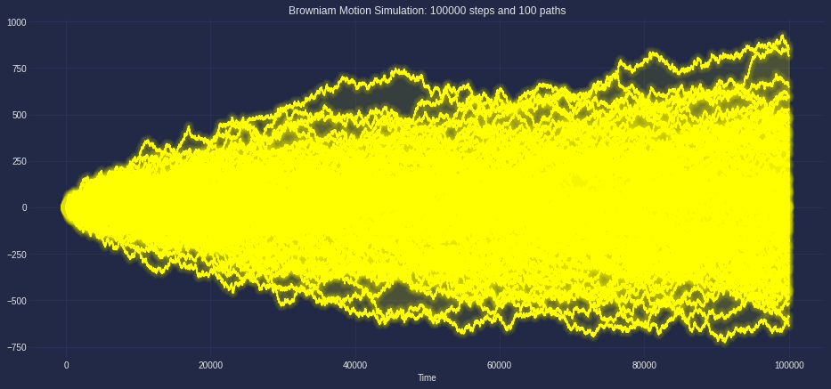

```python
# Brownian motion
plt.figure(figsize=(16,7))
for i in range(bm_sim.shape[0]):
    plt.plot(list(bm_sim.columns), bm_sim.iloc[i][:], color='yellow')
plt.title('Browniam Motion Simulation: {} steps and {} paths'.format(steps, n))
plt.xlabel('Time')
mplcyberpunk.add_glow_effects()
plt.show()
```

## **2-D Brownian Motion**

[figure not shown]

```python
# Brownian Bridge
plt.figure(figsize=(14,10))
for i in range(bm_sim.shape[0]):
    plt.plot(bm_sim.iloc[0][:], bm_sim.iloc[1][:], color='yellow', linewidth=0.4)
    plt.plot(bm_sim.iloc[0][:], bm_sim.iloc[1][:], 'o', color='yellow', markersize=0.4)
plt.title('Browniam Motion Simulation: {} steps and {} paths'.format(steps, n))
plt.xlabel('Time')
#mplcyberpunk.add_glow_effects()
plt.show()
```

# **Puente Browniano**

**Definición:**

Un procesos estocástico $\{X(t)= B(t) - \frac{t}{T} B(T) , 0 \leq t \leq T \}$, es un puente Browniano si satisface las siguientes propiedades:

1.- $X(0)=X(T)=0$

2.- $X(t)$ se distribuye como una normal con media cero y varianza $t(1-t/T)$

$$E(X(t)) = 0$$

, y $$Var(X(t)) = t(1-t/T)$$

3.- $Cov(X(s), X(t)) = min(s, t) - \frac{st}{T}$

```python
# simulation
steps = 100000
n = 100 # paths
bm_sim = StochasticSimulation(steps=steps, n_times=n).BrownianBridge()
bm_sim.shape
```

```
(100, 100001)
```

## **1-D Brownian Bridge**

[figure not shown]

```python
# Brownian Bridge
plt.figure(figsize=(16,7))
for i in range(bm_sim.shape[0]):
    plt.plot(list(bm_sim.columns), bm_sim.iloc[i][:], color='yellow')
plt.title('Browniam Bridge Simulation: {} steps and {} paths'.format(steps, n))
plt.xlabel('Time')
mplcyberpunk.add_glow_effects()
plt.show()
```

## **2-D Brownian Bridge**

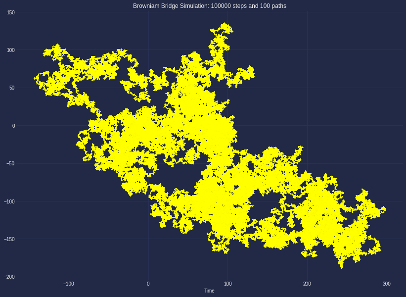

```python
# Brownian Bridge
plt.figure(figsize=(14,10))
for i in range(bm_sim.shape[0]):
    plt.plot(bm_sim.iloc[0][:], bm_sim.iloc[1][:], color='yellow', linewidth=0.4)
    plt.plot(bm_sim.iloc[0][:], bm_sim.iloc[1][:], 'o', color='yellow', markersize=0.4)
plt.title('Browniam Bridge Simulation: {} steps and {} paths'.format(steps, n))
plt.xlabel('Time')
#mplcyberpunk.add_glow_effects()
plt.show()
```

# **Caminata aleatoria simple**

La caminata aleatoria en $\mathbb{Z}$, es la más simple de todas, de ahí su nombre. $X_i$ toma valores en $\{−1,1\}$, y la caminata comienza en $S_n = 0$ y está definida para valores enteros. Las probabilidades de ir a la derecha o a la izquierda se denotan como $P(X_i=1)$ y $P(X_i=-1)$, respectivamente, con las siguientes probabilidades para el caso de una caminata aleatoria simétrica:

\begin{equation*} P(X_i=1)=P(X_i=−1)=1/2 \end{equation*}

Considerando el caso más general, se tiene que el caminante puede ir a la derecha con probabilidad $p$, y a la izquierda con probabilidad $1-p$

\begin{equation*} P(X_i=1)=p \ \text{ y } \ P(X_i=−1)=1−p \end{equation*}

```python
# simulation
steps = 100000
n = 100 # paths
bm_sim = StochasticSimulation(steps=steps, n_times=n).SimpleRandomWalk(p=0.5)
bm_sim.shape
```

```
(100, 100001)
```

## **1-D Random Walk**

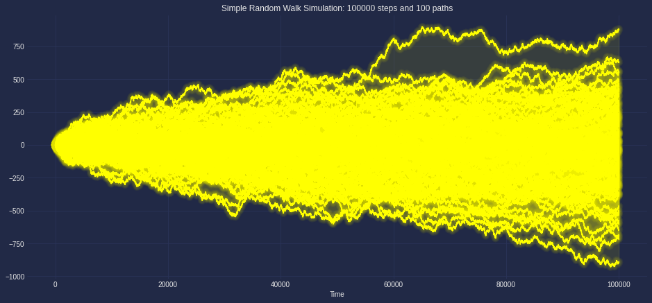

```python
# Simple Random Walk
plt.figure(figsize=(16,7))
for i in range(bm_sim.shape[0]):
    plt.plot(list(bm_sim.columns), bm_sim.iloc[i][:], color='yellow')
plt.title('Simple Random Walk Simulation: {} steps and {} paths'.format(steps, n))
plt.xlabel('Time')
mplcyberpunk.add_glow_effects()
plt.show()
```

## **2-D Random Walk**

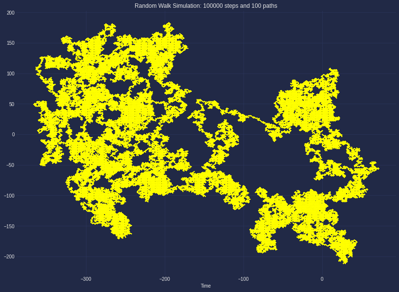

```python
# Brownian Bridge
plt.figure(figsize=(14,10))
for i in range(bm_sim.shape[0]):
    plt.plot(bm_sim.iloc[0][:], bm_sim.iloc[1][:], color='yellow', linewidth=0.4)
    plt.plot(bm_sim.iloc[0][:], bm_sim.iloc[1][:], 'o', color='yellow', markersize=0.4)
plt.title('Random Walk Simulation: {} steps and {} paths'.format(steps, n))
plt.xlabel('Time')
#mplcyberpunk.add_glow_effects()
plt.show()
```

# **Movimiento Browniano con deriva y volatilidad**

**Definición:**

Sea $\{B(t), t \geq 0\}$ un movimiento Browniano estándar. El procesos estocástico $\{X(t)= \mu t + \sigma B(t), t \geq 0\}$ recibe el nombre de movimiento Browniano con coeficiente de deriva (drift) $\mu$, y coeficiente de volatilidad (o difusión) $\sigma$.

**Poposición**

La distribucuión de $X(t)$ es normal con media $\mu t$, y varianza $\sigma^2 t$. Y la covarianza entre $X(s)$ y $X(t)$ es $$Cov(X(s), X(t)) = \sigma^2 min(s, t)$$.

```python
# simulación
steps = 100000
n = 100 # paths
bmd_sim = StochasticSimulation(steps=steps, n_times=n).BrownianMotionDrift(mu=1.4, sigma=0.8)
bmd_sim.shape
```

```
(100, 100001)
```

## **1-D Movimiento Browniano con deriva y volatilidad**

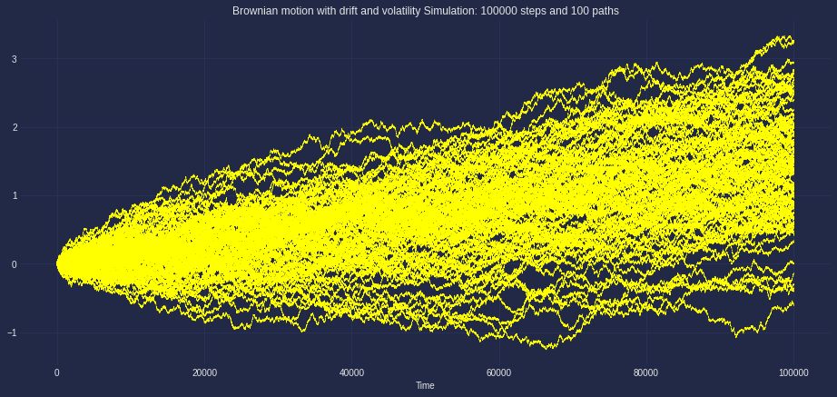

```python
# Brownian motion with drift and volatility
plt.figure(figsize=(16,7))
for i in range(bmd_sim.shape[0]):
    plt.plot(list(bmd_sim.columns), bmd_sim.iloc[i][:], color='yellow', linewidth=0.4)
plt.title('Brownian motion with drift and volatility Simulation: {} steps and {} paths'.format(steps, n))
plt.xlabel('Time')
#mplcyberpunk.add_glow_effects()
plt.show()
```

## **2-D Movimiento Browniano con deriva y volatilidad**

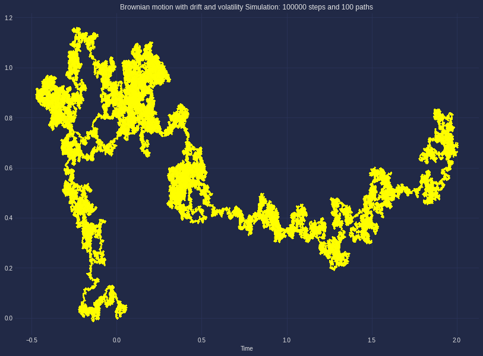

```python
# Brownian motion with drift and volatility
plt.figure(figsize=(14,10))
for i in range(bmd_sim.shape[0]):
  plt.plot(bmd_sim.iloc[0][:], bmd_sim.iloc[1][:], color='yellow', linewidth=0.4)
  plt.plot(bmd_sim.iloc[0][:], bmd_sim.iloc[1][:], 'o', color='yellow', markersize=0.4)
plt.title('Brownian motion with drift and volatility Simulation: {} steps and {} paths'.format(steps, n))
plt.xlabel('Time')
#mplcyberpunk.add_glow_effects()
plt.show()
```

# **Movimiento Browniano Geométrico**

```python
# simulation
steps = 100000
n = 100 # paths
S0 = 7.1
alpha=0.3
beta=0.08
gbm_sim = StochasticSimulation(steps=steps, n_times=n).GeometricBrownianMotion(S0=S0, alpha=alpha, beta=beta)
gbm_sim.shape
```

```
(100, 100001)
```

## **1-D Movimiento Browniano Geométrico**

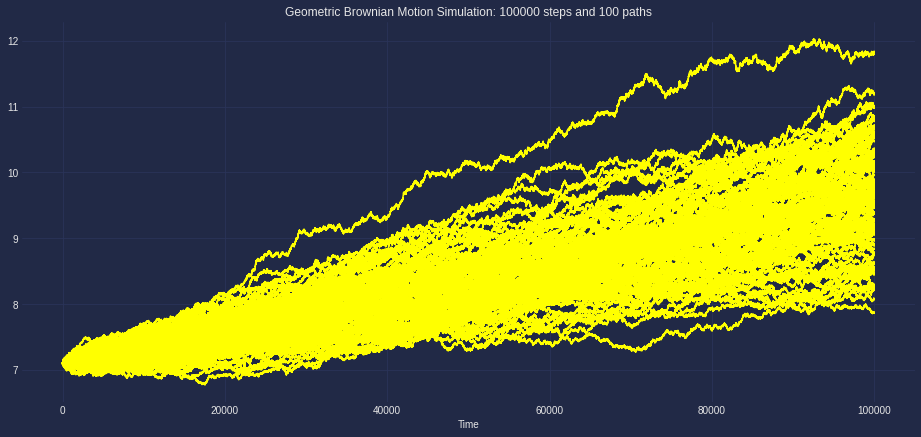

```python
# Geometric Brownian motion
plt.figure(figsize=(16,7))
for i in range(gbm_sim.shape[0]):
    plt.plot(list(gbm_sim.columns), gbm_sim.iloc[i][:], color='yellow')
plt.title('Geometric Brownian Motion Simulation: {} steps and {} paths'.format(steps, n))
plt.xlabel('Time')
#mplcyberpunk.add_glow_effects()
plt.show()
```

## **2-D Movimiento Browniano Geométrico**

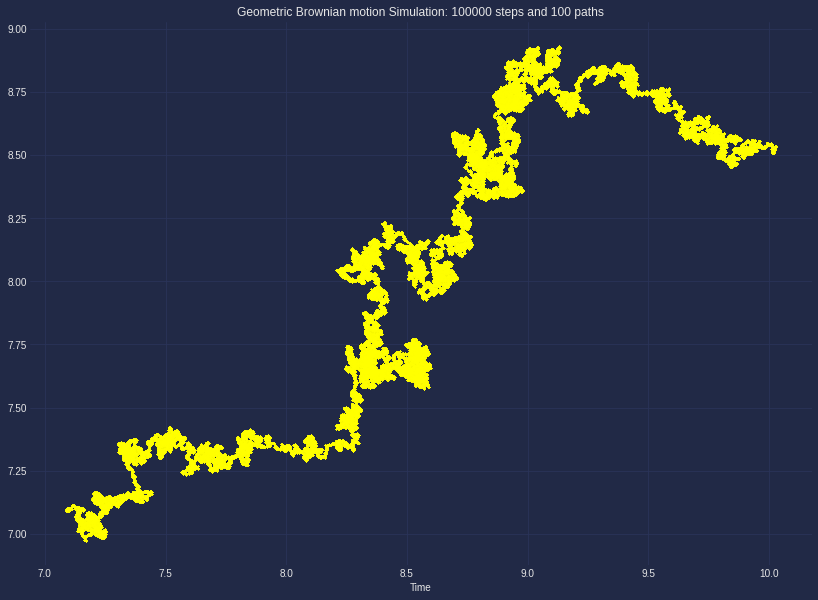

```python
# Geometric Brownian Motion
plt.figure(figsize=(14,10))
for i in range(gbm_sim.shape[0]):
  plt.plot(gbm_sim.iloc[0][:], gbm_sim.iloc[1][:], color='yellow', linewidth=0.4)
  plt.plot(gbm_sim.iloc[0][:], gbm_sim.iloc[1][:], 'o', color='yellow', markersize=0.4)
plt.title('Geometric Brownian motion Simulation: {} steps and {} paths'.format(steps, n))
plt.xlabel('Time')
#mplcyberpunk.add_glow_effects()
plt.show()
```